# Demand Forecasting - BS1808 Logistics and Supply Chain Analytics - Store 12631

```r
#accuracy of the Holt Winters soplitted data forecast
accuracy(ts_store12631_HW_F, ts_store12631_V)
```

```
                   ME     RMSE      MAE        MPE     MAPE      MASE        ACF1
Training set 4.070078 39.68157 30.57662 -0.4378165 11.64796 0.7210208 -0.02731284
Test set     8.269454 44.57013 38.71534  0.5922732 13.68837 0.9129381          NA
```

```r
# ETS forecast with splitted data
ts_store12631_ETS_T <- ets(ts_store12631_T, model = "MNM")
ts_store12631_ETS_F <- forecast.ets(ts_store12631_ETS_T, h = 20)
```

```r
# ETS Forecast Splitted Data
plot(ts_store12631_ETS_F, main = 'Store 12631: ETS Forecast with Splitted Data', xlab='Time', ylab='Lettuce Demand per Day in Ounces', col = 'black')
lines(fitted(ts_store12631_ETS_F), col = "skyblue3")
```

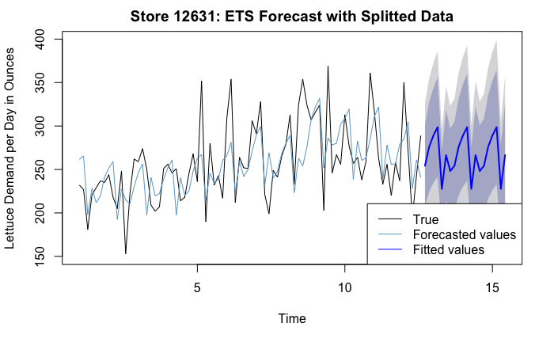

```r
legend('bottomright', legend=c('True','Forecasted values', 'Fitted values'), col=c('black', 'skyblue3', 'blue'), lty=c(1,1,1))
```

```r
#accuracy of the ETS splitted data forecast
accuracy(ts_store12631_ETS_F, ts_store12631_V)
```

```
                   ME     RMSE      MAE        MPE     MAPE      MASE       ACF1
Training set 2.025111 35.05182 26.63933 -0.8240822 10.28761 0.6281764 -0.0429736
Test set     8.663128 44.59696 36.87301  0.7187325 12.94687 0.8694945         NA
```

```r
# Train Model for 14 days Holt Winters Forecast
ts_store12631_ETS_Forecast <- forecast.ets(ts_store12631_ETS, h = 14)
ts_store12631_ETS_Forecast
```

```
         Point Forecast    Lo 80    Hi 80    Lo 95    Hi 95
15.71429       258.1965 209.7455 306.6475 184.0971 332.2959
15.85714       276.1955 224.0706 328.3205 196.4773 355.9138
16.00000       302.6475 245.2074 360.0877 214.8004 390.4947
16.14286       307.1361 248.5179 365.7542 217.4873 396.7848
16.28571       233.2254 188.4671 277.9838 164.7735 301.6774
16.42857       266.3445 214.9505 317.7386 187.7441 344.9449
16.57143       246.8641 198.9710 294.7571 173.6179 320.1102
16.71429       258.1966 207.8360 308.5572 181.1766 335.2165
16.85714       276.1956 222.0386 330.3526 193.3696 359.0216
17.00000       302.6476 242.9923 362.3029 211.4127 393.8826
17.14286       307.1361 246.2815 367.9908 214.0670 400.2053
17.28571       233.2255 186.7775 279.6735 162.1894 304.2616
17.42857       266.3446 213.0306 319.6586 184.8079 347.8813
17.57143       246.8641 197.2003 296.5279 170.9099 322.8183
```

```r
#ETS Forecast
plot(ts_store12631_ETS_Forecast, main = 'ETS Forecast', xlab='Time', ylab='Lettuce Demand per Day in Ounces', lty = 1, col = "black")
lines(fitted(ts_store12631_ETS_Forecast), col = 'skyblue3')
legend('bottomright', legend=c('True','Forecasted values', 'Fitted values'), col=c('black', 'skyblue3', 'blue'), lty=c(1,1,1))
```

[output not shown]

```r
plot(acf(ts_store12631_ETS_Forecast$residuals,main = 'ETS Forecast', lag.max=20), main = 'ACF of ETS')
```

[output not shown]

```r
plot.ts(ts_store12631_ETS_Forecast$residuals, main='ETS Forecast Error over time', xlab='Time', ylab='Residuals', col = 'darkblue')
```

[output not shown]

```r
# Ljung-Box Test to check whether the error is independently distributed
Box.test(ts_store12631_ETS_Forecast$residuals, lag=20, type='Ljung-Box')
```

[output not shown]

Null Hypothesis: indendetly distributed data p-value sufficently large => not rejecting the null hypothesis and therefore assume independence of the error term

```r
# Argumented Dickey Fuller Test to check whether data is stationary
tseries::adf.test(ts_store12631_ETS_Forecast$residuals)
```

[output not shown]

Null Hypothesis: non-stationary p-value< 0.05 => reject the null hypothesis at a significance level of 5% => stationary

```r
#Box-Pierce to check whether data is autocorrelated
Box.test(ts_store12631_ETS_Forecast, type='Box-Pierce')
```

[output not shown]

Null Hypothesis: zero autocorrelation p-value sufficently large => not rejecting the null hypothesis => no autocorrelation

###ARIMA###

###testing (stationarity, iid, autocorrelation)###

```r
# Ljung-Box Test to check whether data is independently distributed
Box.test(ts_store12631, type='Ljung-Box')
```

[output not shown]

Null Hypothesis: indendetly distributed data p-value very small => rejection of null hypothesis and therefore assume dependence

```r
# Argumented Dickey Fuller Test to check whether data is stationary
tseries::adf.test(ts_store12631)
```

[output not shown]

```r
#KPSS test for level of stationarity
kpss.test(ts_store12631)
```

[output not shown]

```r
#Box-Pierce to check whether data is autocorrelated
Box.test(ts_store12631, type='Box-Pierce')
```

[output not shown]

Null Hypothesis: zero autocorrelation p-value very small => reject the null hypothesis => autocorrelation

```r
#Philips-Perron Test to check order/existence of autocorrelation
tseries:::pp.test(ts_store12631)
```

[output not shown]

Null Hypothesis: non-stationary p-value smaller than printed p-value => reject the null hypothesis => stationary

```r
# taking the logarithm of the entire time series
ts_store12631_log <- log(ts_store12631)
```

```r
ts_store12631_log_D1 <- diff(ts_store12631_log, differences = 1)
```

```r
# Ljung-Box Test to check whether log first difference data is independently distributed
Box.test(ts_store12631_log_D1, type='Ljung-Box')
```

[output not shown]

Null Hypothesis: indendetly distributed data p-value very small => rejection of null hypothesis and therefore assume dependence

```r
# Argumented Dickey Fuller Test to check whether log and first difference data is stationary
tseries::adf.test(ts_store12631_log_D1)
```

[output not shown]

Null Hypothesis: non-stationary p-value smaller than printed p-value => reject the null hypothesis =>trend-stationary

```r
#KPSS test for level of stationarity for log and first difference data
kpss.test(ts_store12631_log_D1)
```

[output not shown]

```r
#Box-Pierce to check whether log and first difference data is autocorrelated
Box.test(ts_store12631_log_D1, type='Box-Pierce')
```

[output not shown]

Null Hypothesis: zero autocorrelation p-value very small => reject the null hypothesis => autocorrelation

```r
#Philips-Perron Test to check order/existence of autocorrelation for log and first difference data
tseries:::pp.test(ts_store12631_log_D1)
```

[output not shown]

Null Hypothesis: non-stationary p-value smaller than printed p-value => reject the null hypothesis => stationary

```r
#number of additional differences in order to make the time series stationary
forecast:::ndiffs(ts_store12631_log_D1)
```

```
[1] 0
```

```r
#number of seasonal difference in order to make the time series stationary
forecast:::nsdiffs(ts_store12631_log_D1)
```

```
[1] 0
```

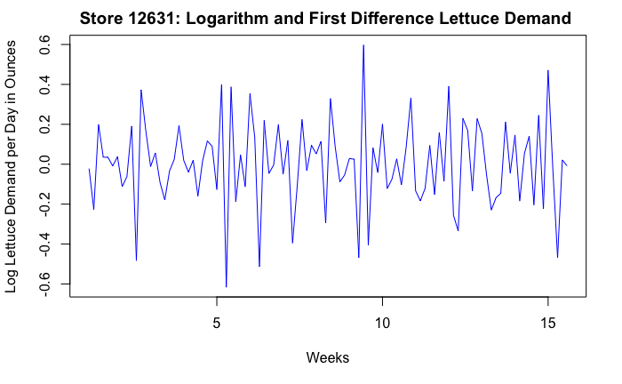

```r
#plotting the time series data
plot.ts(ts_store12631_log_D1, main='Store 12631: Logarithm and First Difference Lettuce Demand ', xlab='Weeks', ylab='Log Lettuce Demand per Day in Ounces', col = 'blue')
```

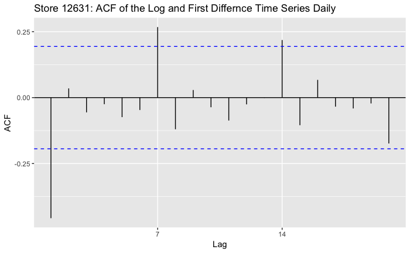

```r
# ACF of original time series
ggAcf(ts_store12631_log_D1, main = 'Store 12631: ACF of the Log and First Differnce Time Series Daily')
```

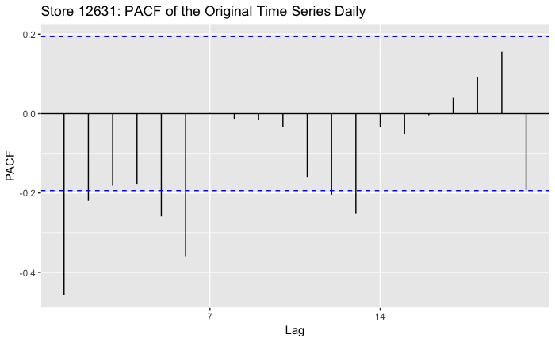

```r
ggPacf(ts_store12631_log_D1, main = 'Store 12631: PACF of the Original Time Series Daily')
```

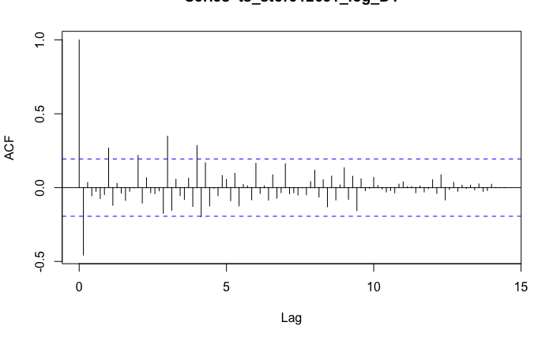

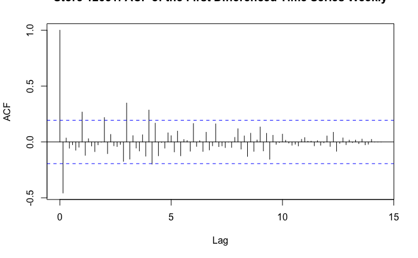

```r
# ACF of first differenced time series
plot(acf(ts_store12631_log_D1 , lag.max = 200), main = 'Store 12631: ACF of the First Differenced Time Series Weekly')
```

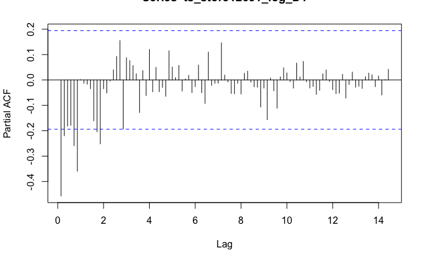

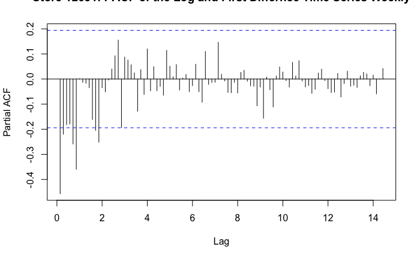

```r
# PACF of first differenced time series
plot(pacf(ts_store12631_log_D1 , lag.max = 200), main = 'Store 12631: PACF of the Log and First Differnce Time Series Weekly')
```

```r
#auto ARIMA
forecast:::auto.arima(ts_store12631, trace = TRUE, ic = 'bic', approximation = FALSE, lambda=0)
```

```
 ARIMA(2,1,2)(1,0,1)[7] with drift         : Inf
 ARIMA(0,1,0)           with drift         : -12.91423
 ARIMA(1,1,0)(1,0,0)[7] with drift         : -38.898
 ARIMA(0,1,1)(0,0,1)[7] with drift         : -60.34469
 ARIMA(0,1,0)                              : -17.5392
 ARIMA(0,1,1)           with drift         : -59.92277
 ARIMA(0,1,1)(1,0,1)[7] with drift         : Inf
 ARIMA(0,1,1)(0,0,2)[7] with drift         : -61.61351
 ARIMA(0,1,1)(1,0,2)[7] with drift         : Inf
 ARIMA(0,1,0)(0,0,2)[7] with drift         : -10.87872
 ARIMA(1,1,1)(0,0,2)[7] with drift         : -57.49675
 ARIMA(0,1,2)(0,0,2)[7] with drift         : -57.43068
 ARIMA(1,1,0)(0,0,2)[7] with drift         : -32.82244
 ARIMA(1,1,2)(0,0,2)[7] with drift         : Inf
 ARIMA(0,1,1)(0,0,2)[7]                    : -64.85399
 ARIMA(0,1,1)(0,0,1)[7]                    : -63.50695
 ARIMA(0,1,1)(1,0,2)[7]                    : Inf
 ARIMA(0,1,1)(1,0,1)[7]                    : Inf
 ARIMA(0,1,0)(0,0,2)[7]                    : -15.50359
 ARIMA(1,1,1)(0,0,2)[7]                    : -60.57924
 ARIMA(0,1,2)(0,0,2)[7]                    : -60.5449
 ARIMA(1,1,0)(0,0,2)[7]                    : -37.44729
 ARIMA(1,1,2)(0,0,2)[7]                    : -56.00606

 Best model: ARIMA(0,1,1)(0,0,2)[7]

Series: ts_store12631
ARIMA(0,1,1)(0,0,2)[7]
Box Cox transformation: lambda= 0

Coefficients:
          ma1    sma1    sma2
      -0.9211  0.1488  0.2135
s.e.   0.0375  0.1146  0.0879

sigma^2 estimated as 0.02603:  log likelihood=41.68
AIC=-75.35   AICc=-74.94   BIC=-64.85
```

```r
#Fitting training data set on ARIMA option 1
ts_store12631_ARIMA1_T <- Arima(ts_store12631_T, order = c(0, 1, 1),seasonal = list(order = c(0, 0, 2), period = 7))
```

```r
#Forecasting training data set for ARIMA option 1
ts_store12631_ARIMA1_T_F<- forecast:::forecast.Arima(ts_store12631_ARIMA1_T, h = 20)
```

```r
# Accuracy Forecasting training data set for ARIMA option 1
forecast:::accuracy(ts_store12631_ARIMA1_T_F, ts_store12631_V)
```

```
                   ME     RMSE      MAE        MPE     MAPE      MASE        ACF1
Training set 3.988187 40.03366 30.49155 -0.5804026 11.76543 0.7190148 -0.02141623
Test set     9.500946 51.48256 41.67803  0.3654383 14.48574 0.9828007          NA
```

```r
#Fitting training data set on ARIMA option 2
ts_store12631_ARIMA2_T <- Arima(ts_store12631_T, order = c(1, 1, 0),seasonal = list(order = c(0, 0, 2), period = 7))
```

```r
#Forecasting training data set for ARIMA option 2
ts_store12631_ARIMA2_T_F<- forecast:::forecast.Arima(ts_store12631_ARIMA2_T, h = 20)
```

```r
# Accuracy Forecasting training data set for ARIMA option 2
forecast:::accuracy(ts_store12631_ARIMA2_T_F, ts_store12631_V)
```

```
                      ME     RMSE      MAE       MPE     MAPE      MASE       ACF1
Training set   0.7701684 45.64705 33.92964 -1.819506 13.42126 0.8000876 -0.1372294
Test set     -13.7778021 53.42525 47.80388 -8.420315 18.07660 1.1272531         NA
```

```r
#Fitting training data set on ARIMA option 3
ts_store12631_ARIMA3_T<- Arima(ts_store12631_T, order = c(0, 1, 1),seasonal = list(order = c(1, 0, 2), period = 7))
```

```r
#Forecasting training data set for ARIMA option 3
ts_store12631_ARIMA3_T_F<- forecast:::forecast.Arima(ts_store12631_ARIMA3_T, h = 20)
```

```r
# Accuracy Forecasting training data set for ARIMA option 3
forecast:::accuracy(ts_store12631_ARIMA3_T_F, ts_store12631_V)
```

```
                    ME     RMSE      MAE       MPE     MAPE      MASE        ACF1
Training set 0.5057486 37.65035 28.86753 -1.684107 11.25146 0.6807190 -0.02000808
Test set     2.2919052 44.72573 38.77189 -1.841052 13.90504 0.9142716          NA
```

```r
#complete 14 days forecast with ARIMA1
ts_store12631_ARIMA1_C <- Arima(ts_store12631, order = c(0, 1, 1),seasonal = list(order = c(1, 0, 2), period = 7))
ts_store12631_ARIMA1_CF<- forecast:::forecast.Arima(ts_store12631_ARIMA1_C, h = 14)
ts_store12631_ARIMA1_CF
```

```
         Point Forecast    Lo 80    Hi 80    Lo 95    Hi 95
15.71429       264.7001 213.0880 316.3122 185.7662 343.6340
15.85714       274.0861 222.2479 325.9242 194.8065 353.3657
16.00000       311.9079 259.8446 363.9711 232.2840 391.5317
16.14286       291.7051 239.4178 343.9925 211.7385 371.6717
16.28571       245.1405 192.6301 297.6510 164.8327 325.4484
16.42857       265.0148 212.2822 317.7475 184.3672 345.6625
16.57143       247.7588 194.8048 300.7127 166.7727 328.7448
16.71429       268.3151 214.5908 322.0394 186.1508 350.4794
16.85714       270.4156 216.4371 324.3941 187.8626 352.9685
17.00000       316.3543 262.1225 370.5861 233.4139 399.2947
17.14286       297.8680 243.3845 352.3516 214.5426 381.1934
17.28571       245.5375 190.8033 300.2717 161.8288 329.2462
17.42857       263.0629 208.0793 318.0465 178.9727 347.1531
17.57143       247.7728 192.5408 303.0047 163.3028 332.2428
```

```r
#plotting complete 14 day ARIMA1 forecast
#ETS Forecast
plot(ts_store12631_ARIMA1_CF, main = 'ARMIA(0,1,1)(1,0,2)(7) Forecast', xlab='Time', ylab='Lettuce Demand per Day in Ounces', lty = 1, col = "black")
lines(fitted(ts_store12631_ARIMA1_CF), col = 'skyblue3')
```

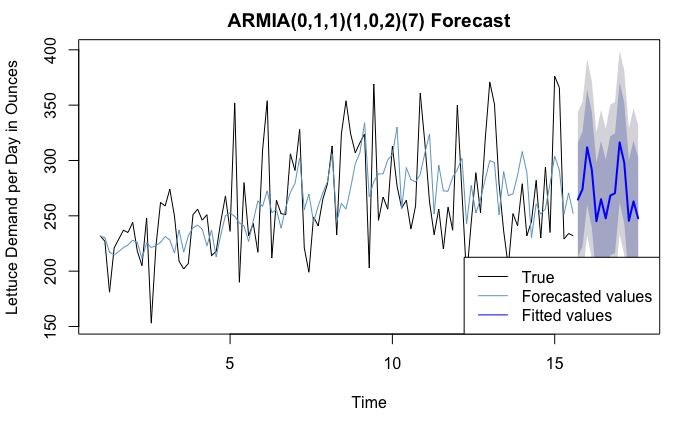

```r
legend('bottomright', legend=c('True','Forecasted values', 'Fitted values'), col=c('black', 'skyblue3', 'blue'), lty=c(1,1,1))
```

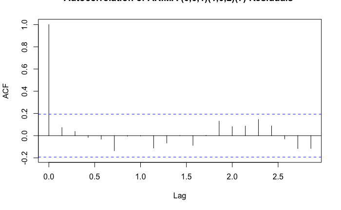

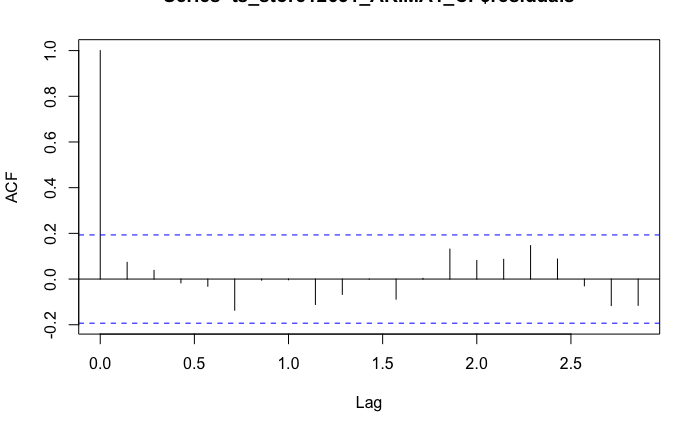

```r
plot(acf(ts_store12631_ARIMA1_CF$residuals,main = 'Autocorrelation of ARIMA (0,0,1)(1,0,2)(7) Residuals ', lag.max=20))
```

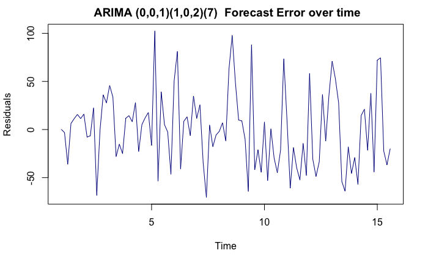

```r
plot.ts(ts_store12631_ARIMA1_CF$residuals, main=' ARIMA (0,0,1)(1,0,2)(7)  Forecast Error over time', xlab='Time', ylab='Residuals', col = 'darkblue')
```

```r
# Ljung-Box Test to check whether the error is independently distributed
Box.test(ts_store12631_ARIMA1_CF$residuals, lag=20, type='Ljung-Box')
```

```
    Box-Ljung test

data:  ts_store12631_ARIMA1_CF$residuals
X-squared = 16.733, df = 20, p-value = 0.6702
```

```r
# Argumented Dickey Fuller Test to check whether data is stationary
tseries::adf.test(ts_store12631_ARIMA1_CF$residuals)
```

```
p-value smaller than printed p-value
```

```
    Augmented Dickey-Fuller Test

data:  ts_store12631_ARIMA1_CF$residuals
Dickey-Fuller = -5.1952, Lag order = 4, p-value = 0.01
alternative hypothesis: stationary
```

```r
#Box-Pierce to check whether data is autocorrelated
Box.test(ts_store12631_ARIMA1_CF$residuals, type='Box-Pierce')
```

```
    Box-Pierce test

data:  ts_store12631_ARIMA1_CF$residuals
X-squared = 0.55027, df = 1, p-value = 0.4582
```

```r
#conductiong the final 14 days forecast
store12631_RESULTS <- forecast.ets(ts_store12631_ETS, h = 14)
store12631_RESULTS
```

```
         Point Forecast    Lo 80    Hi 80    Lo 95    Hi 95
15.71429       258.1965 209.7455 306.6475 184.0971 332.2959
15.85714       276.1955 224.0706 328.3205 196.4773 355.9138
16.00000       302.6475 245.2074 360.0877 214.8004 390.4947
16.14286       307.1361 248.5179 365.7542 217.4873 396.7848
16.28571       233.2254 188.4671 277.9838 164.7735 301.6774
16.42857       266.3445 214.9505 317.7386 187.7441 344.9449
16.57143       246.8641 198.9710 294.7571 173.6179 320.1102
16.71429       258.1966 207.8360 308.5572 181.1766 335.2165
16.85714       276.1956 222.0386 330.3526 193.3696 359.0216
17.00000       302.6476 242.9923 362.3029 211.4127 393.8826
17.14286       307.1361 246.2815 367.9908 214.0670 400.2053
17.28571       233.2255 186.7775 279.6735 162.1894 304.2616
17.42857       266.3446 213.0306 319.6586 184.8079 347.8813
17.57143       246.8641 197.2003 296.5279 170.9099 322.8183
```

```r
#save the results as CSV
write.csv(store12631_RESULTS, 'store12631_RESULTS.csv')
```